# Algo (muito rápido) sobre o ggplot2

### 5.1 Ridgeline (Joyplot)

- Carregue (se preciso, instale-o antes) o pacote `ggridges`

```r
# install.packages("ggridges")
library(ggridges)
```

- Usaremos a função `geom_density_ridges()`

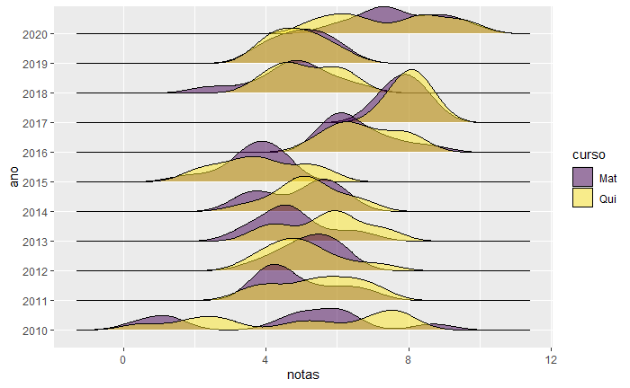

```r
notas_tidy %>%
  ggplot() +
  aes(x = notas, y = ano, fill = curso) +
  geom_density_ridges(alpha = 0.5) +
  scale_fill_viridis_d()
```

- Podemos filtrar por um curso específico, por exemplo, Química.

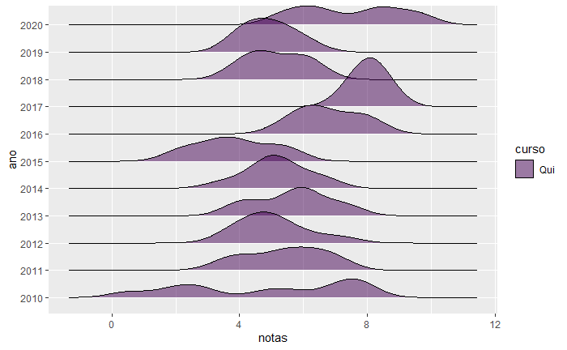

```r
notas_tidy %>%
  filter(curso == "Qui") %>%
  ggplot() +
  aes(x = notas, y = ano, fill = curso) +
  geom_density_ridges(alpha = 0.5) +
  scale_fill_viridis_d()
```

## 6. Boxplot

- Já vimos muito sobre boxplot em nossa disciplina (inclusive artigos que explicam os pormenores)
- Para exemplificar, continuaremos com o *dataset* `notas_tidy`.
  - inicialmente, vamos comparar, ao logo dos anos, os boxplots dos cursos

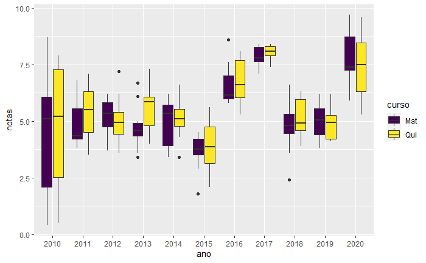

```r
notas_tidy %>%
  ggplot() +
  aes(x = ano, y= notas, fill = curso) +
  geom_boxplot() +
  scale_fill_viridis_d()
```

- Agora, vamos comparar apenas as notas ao longo dos anos.
  - se quisermos omitir as legendas, usamos `show.legend = FALSE`

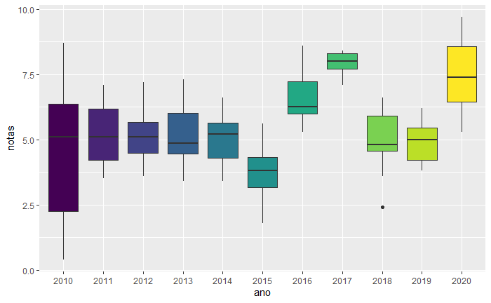

```r
notas_tidy %>%
  ggplot() +
  aes(x = ano, y= notas) +
  geom_boxplot(aes(fill = ano), show.legend = FALSE) +
  scale_fill_viridis_d()
```

## Extra: reta vertical e anotações

- Considere a densidade das notas do curso:

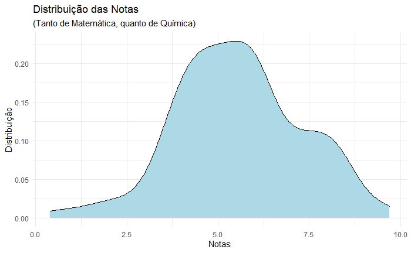

```r
notas_tidy %>%
  ggplot() +
  aes(x = notas) +
  geom_density(fill = "lightblue") +
  labs(
    title = "Distribuição das Notas",
    subtitle = "(Tanto de Matemática, quanto de Química)",
    x = "Notas",
    y = "Distribuição"
  ) +
  theme_minimal()
```

- Como representar, por exemplo, a média dessas notas com uma reta vertical?

[figure not shown]

```r
notas_tidy %>%
  ggplot() +
  aes(x = notas) +
  geom_density(fill = "lightblue", alpha = 0.6) +
  labs(
    title = "Distribuição das Notas",
    subtitle = "(Tanto de Matemática, quanto de Química)",
    x = "Notas",
    y = "Distribuição"
  ) +
  theme_minimal() +
  geom_vline(aes(xintercept = mean(notas)), color = "red")
```

- E se quisermos colocar o nome “Média” nessa reta?

[figure not shown]

```r
notas_tidy %>%
  ggplot() +
  aes(x = notas) +
  geom_density(fill = "lightblue", alpha = 0.6) +
  geom_vline(aes(xintercept = mean(notas)), color = "red") +
  labs(
    title = "Distribuição das Notas",
    subtitle = "(Tanto de Matemática, quanto de Química)",
    x = "Notas",
    y = "Distribuição"
  ) +
  theme_minimal() +
  annotate("text", x = 6, y = 0.05, label = "Média", color = "red")
```